# Intrepid Potash

Chris Trivino

May 18, 2021

```r
# Use this R-Chunk to import all your !



intrepid$NS1M1[intrepid$NS1M1=="[-11059] No Good Data For Calculation"]<-NA
intrepid$NS1M1 <-as.numeric(intrepid$NS1M1)

intrepid$NS2M1[intrepid$NS2M1=="[-11059] No Good Data For Calculation"]<-NA
intrepid$NS2M1 <-as.numeric(intrepid$NS2M1)

intrepid$NS2M2[intrepid$NS2M2=="[-11059] No Good Data For Calculation"]<-NA
intrepid$NS2M2 <-as.numeric(intrepid$NS2M2)

intrepid$RollGap1[intrepid$RollGap1=="[-11059] No Good Data For Calculation"]<-NA
intrepid$RollGap1 <-as.numeric(intrepid$RollGap1)

intrepid$RollGap2[intrepid$RollGap2=="[-11059] No Good Data For Calculation"]<-NA
intrepid$RollGap2 <-as.numeric(intrepid$RollGap2)

intrepid$NS1Gate[intrepid$NS1Gate=="[-11059] No Good Data For Calculation"]<-NA
intrepid$NS1Gate <-as.numeric(intrepid$NS1Gate)

intrepid$NS2Gate[intrepid$NS2Gate=="[-11059] No Good Data For Calculation"]<-NA
intrepid$NS2Gate <-as.numeric(intrepid$NS2Gate)

intrepid$BinLevel[intrepid$BinLevel=="[-11059] No Good Data For Calculation"]<-NA
intrepid$BinLevel <-as.numeric(intrepid$BinLevel)

intrepid$NS2Gate[intrepid$NS2Gate=="[-11059] No Good Data For Calculation"]<-NA
intrepid$NS2Gate <-as.numeric(intrepid$NS2Gate)



dat <- intrepid %>% filter(Method == "clamshells", intrepid$Product == 230)

dat <- intrepid %>% filter(Method == "clamshells", intrepid$Product == 230)


dat$NS1Diff <- dat$NS1M2-dat$NS1M1

data1 <- subset(dat, select = -c(Method, Product,Time))

data1 <- data1 %>% filter(AvgBelt6TPHTime>0)

data2 <- data1 %>% select(c(AvgBelt6TPHTime,NS1Diff, NS1M1, NS1M2,Tumbler))
```

## Trying to find linear models

This can help me get off to a start.

```r
mylm <- lm(AvgBelt6TPHTime ~ . , data = data1 )

pander(summary(mylm))
```

|  | Estimate | Std. Error | t value | Pr(>\|t\|) |
| --- | --- | --- | --- | --- |
| **(Intercept)** | -58.01 | 126.4 | -0.4589 | 0.6463 |
| **CompactorRollSpeed** | 0.263 | 0.01662 | 15.83 | 2.584e-55 |
| **NS1M1** | -0.3855 | 0.04538 | -8.496 | 2.439e-17 |
| **NS1M2** | 0.6362 | 0.01034 | 61.52 | 0 |
| **NS2M1** | -0.129 | 0.04214 | -3.061 | 0.002214 |
| **NS2M2** | 0.143 | 0.01486 | 9.619 | 9.475e-22 |
| **RollGap1** | 3.849 | 14.05 | 0.274 | 0.7841 |
| **BinLevel** | 0.06117 | 0.003651 | 16.75 | 1.303e-61 |
| **PressureDrive** | 0.01467 | 0.002631 | 5.575 | 2.575e-08 |
| **PressureNonDrive** | -0.01117 | 0.0026 | -4.298 | 1.754e-05 |
| **Haulback** | 0.1886 | 0.01613 | 11.69 | 3.111e-31 |
| **NS1Gate** | -0.1878 | 0.02056 | -9.132 | 8.941e-20 |
| **NS2Gate** | -0.08252 | 0.01744 | -4.731 | 2.28e-06 |
| **Tumbler** | -0.9339 | 0.169 | -5.524 | 3.441e-08 |

Fitting linear model: AvgBelt6TPHTime ~ .

| Observations | Residual Std. Error | $R^2$ | Adjusted $R^2$ |
| --- | --- | --- | --- |
| 6111 | 3.868 | 0.8122 | 0.8118 |

```r
mylm2 <-  lm(AvgBelt6TPHTime ~ .^2 , data = data1 )
#pander(summary(mylm2))

mylm3 <-  lm(AvgBelt6TPHTime ~ .^3 , data = data1 )
#pander(summary(mylm3))
```

## Lets take a look at the pairs plots

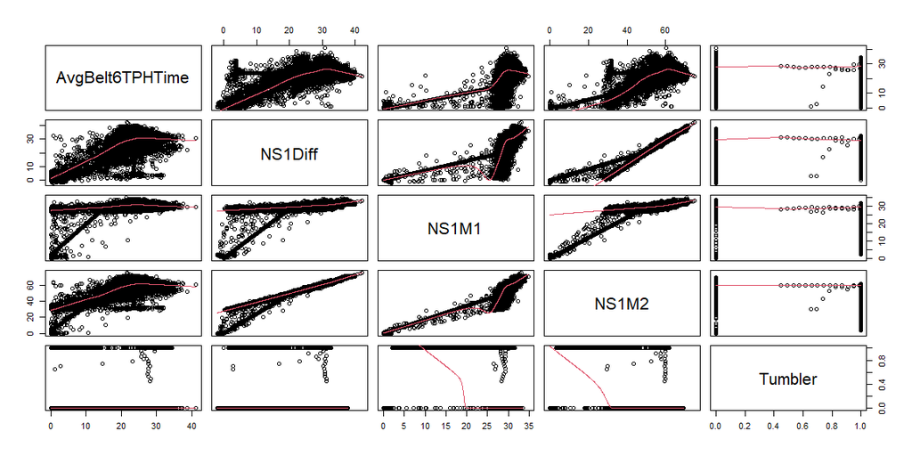

```r
#pairs(cbind(Res = mylm3$res, Fit = mylm3$fit, data1),panel=panel.smooth)
pairs(data2,panel=panel.smooth)
```

## finding a linear model to work with

After much trial and tribulation I found a good lead, but there are still some problems

```r
# Use this R-Chunk to clean & wrangle your data!
lm8 <- lm(AvgBelt6TPHTime~I(NS1Diff^2)+I(NS1Diff^3)+(Tumbler)+CompactorRollSpeed,data1)
pander(summary(lm8)) #.80
```

|  | Estimate | Std. Error | t value | Pr(>\|t\|) |
| --- | --- | --- | --- | --- |
| **(Intercept)** | -5.875 | 0.8868 | -6.625 | 3.778e-11 |
| **I(NS1Diff^2)** | 0.08499 | 0.001051 | 80.84 | 0 |
| **I(NS1Diff^3)** | -0.001876 | 3.072e-05 | -61.06 | 0 |
| **Tumbler** | -1.744 | 0.1432 | -12.18 | 9.211e-34 |
| **CompactorRollSpeed** | 0.1553 | 0.01497 | 10.38 | 5.178e-25 |

Fitting linear model: AvgBelt6TPHTime ~ I(NS1Diff^2) + I(NS1Diff^3) + (Tumbler) + CompactorRollSpeed

| Observations | Residual Std. Error | $R^2$ | Adjusted $R^2$ |
| --- | --- | --- | --- |
| 6113 | 3.895 | 0.8093 | 0.8092 |

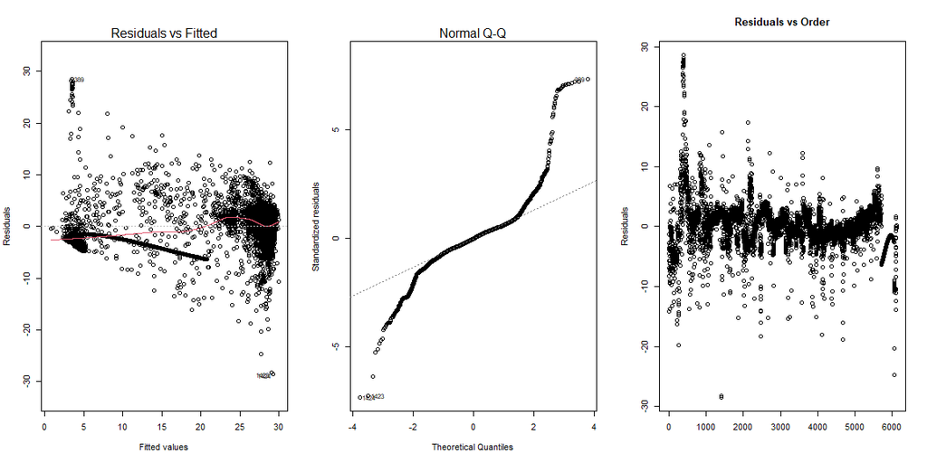

```r
par(mfrow=c(1,3))
plot(lm8, which=1:2)
plot(lm8$residuals, main="Residuals vs Order", xlab="",
     ylab="Residuals")
```

Good news: The model is simple and is 2D explainable.

Bad news: From the diagnostic plots almost every linear assumption is being violated. There are lots of problems.

## Data Visualizations

Time to try and find what’s going on in the data that’s causing my linear assumptions to fail.

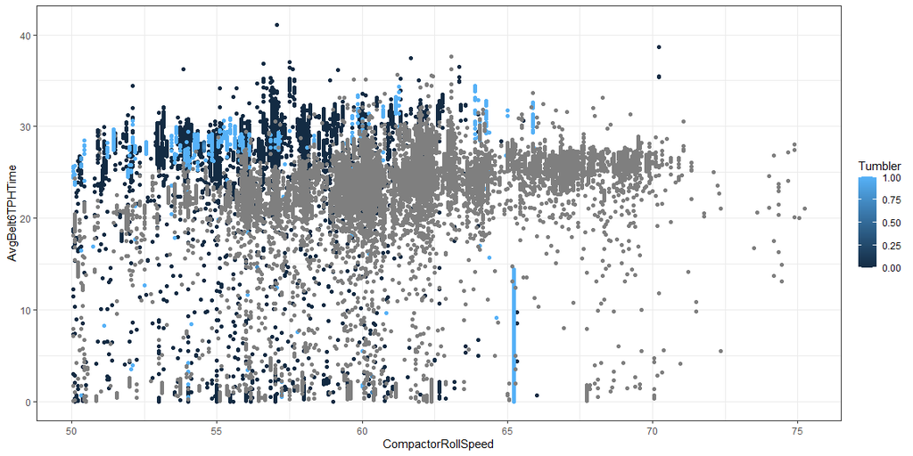

```r
# Use this R-Chunk to plot & visualize your data!

ggplot(data1, aes(x=CompactorRollSpeed,y=AvgBelt6TPHTime, color=Tumbler)) + geom_point(opacity=.3) + theme_bw()
```

hmm.. Why did the compactor roller speed stay at 65 for such a large amount of time? I will have to email our contact with the company.

```r
data1 <- data1 %>% mutate(tumbler_no_na = case_when(Tumbler == 0 ~ "off",
                                           Tumbler ==1 ~ "on",
                                           is.na(Tumbler) ~ "unknown",
                                           TRUE~"unknown"))
```

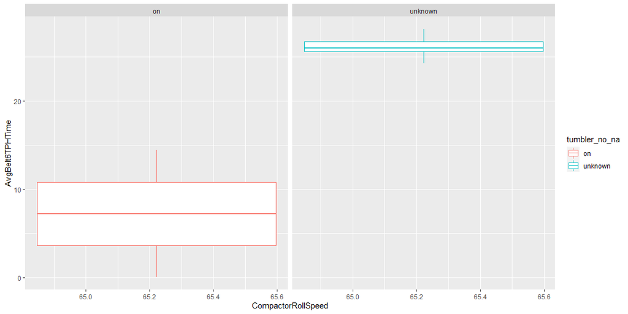

```r
#ggplot(data1, aes(x=CompactorRollSpeed,y=AvgBelt6TPHTime, color=Tumbler)) + geom_point()

data1 %>%
  filter(CompactorRollSpeed>65.2 & CompactorRollSpeed <= 65.26) %>%
  ggplot(aes(x=CompactorRollSpeed,y=AvgBelt6TPHTime, color=tumbler_no_na)) + geom_boxplot()+ facet_wrap(~tumbler_no_na)
```

If I can try and find out if NA’s are zero’s that would help significantly.

## Next step:

You could hire someone helping them understand the NA values in the data set along with the information you provided us. This would help someone with industry experience give you an appropriate regression model faster. Or you could bring the project back to DSS and let students work with the data to help create a linear model.